## SNOMED CT Mapping of the NKDUC

This site is contains additional information about our mapping project, in which we linked clinical concepts of a natioanlly consented dataset for the record keeping of patients with leg ulcer (NKDUC) with the international terminology SNOMED CT.

On this site, we provide the cross-map, which is the pairwise link between the source concepts of the national dataset and SNOMED CT concepts, and the complete analysis of the reliability and the coverage rate of the mapping.

## Cross-Map

The cross-map is available as a csv-file, which can be joined with the reference table of the source dataset (NKDUC) that is also available as csv file.

- [NKDUC Reference](https://github.com/jnshsrs/snomed-nkduc/blob/master/data/mapping-results.csv)
- [Cross-Map](https://github.com/jnshsrs/snomed-nkduc/blob/master/data/mapping-results.csv)

## Coverage Rate and Reliability Analysis

The coverage rate and reliability analysis is available in a python notebook.

- [Coverage Rate and Reliability Analysis](https://jnshsrs.github.io/snomed-nkduc/snomed.html).

**Note:** Additionally, we provide the same analysis as in R which can be found [here](https://jnshsrs.github.io/snomed-nkduc/results-mapping.html).

## Information Model

For the translation from the NKDUC items to SNOMED CT, we identified the NKDUC items that were to be mapped by constructing an information model from the NKDUC, that was initialy published in an tabular structure by its authors.

You can find an aggregated visualisation of our model in the diagram below.

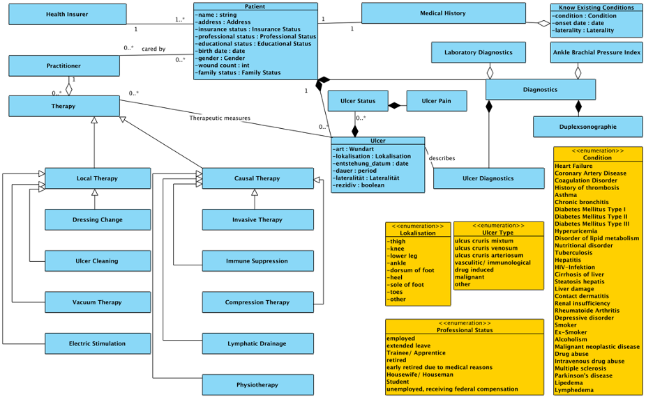

Aggregated Class Diagram